# functional-analysis course homework

Wojciech Dudzik

31/07/2021

# Install all libraries

In case of working on fresh enviroment we can quickly install all the necessary libraries from main CRAN repository.

```r
#install.packages("tidyverse")
#install.packages("ggplot2")
#install.packages("cowplot")
#install.packages("colorDF")
#install.packages("tmod")
#install.packages("colorDF")
#install.packages("broom")
#install.packages("BiocManager")
#BiocManager::install("DESeq2")
#BiocManager::install("msigdbr")
```

# Load libraries

```r
library(tidyverse)
library(ggplot2)
library(cowplot)
library(tmod)
library(colorDF)
library(DESeq2)
library(msigdbr)
```

# Load data

Data provided from https://january3.github.io/FunctionalTranscriptomics/Workshops/workshop_2_1/weiner_functional_transcriptomics_workshop_2_1.html#Homework and is copied to github repository that provides this analysis

```r
counts <- readRDS("data/counts.rds")
covar  <- readRDS("data/covar.rds")
annot  <- readRDS("data/annot.rds")
```

# Build differential gene expression

```r
ds2 <- DESeqDataSetFromMatrix(countData=counts,
                              colData=covar,
                              design= ~ group)
ds2 <- DESeq(ds2)
```

```
## -- replacing outliers and refitting for 305 genes
## -- DESeq argument 'minReplicatesForReplace' = 7
## -- original counts are preserved in counts(dds)
```

# Comparison

In the data we have 3 “classes” - other, no, SC2. We get the coefficients of the one-vs-one-models which show us the differences between healthy examples and specific diseases. We do that so we can compare the change between diseses and healthy baseline. We plot it the logarithm of fold change ratio to check which genes are concodant (located in quarter 1 or 3) and which tends to be discordant (quarter 2 and 4)

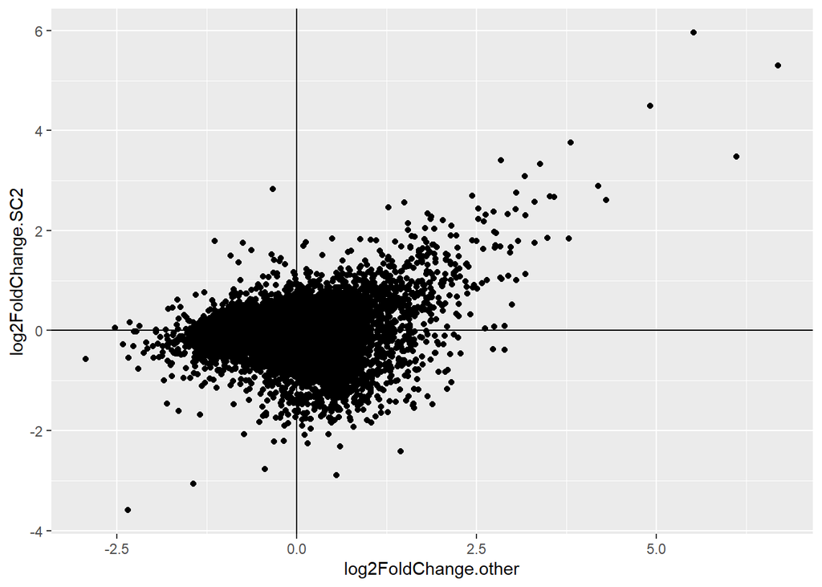

```r
res_other <- results(ds2, name="group_other_vs_no")
res_other <- as.data.frame(res_other)
res_SC2   <- results(ds2, name="group_SC2_vs_no")
res_SC2 <- as.data.frame(res_SC2)
res_merged <- merge(res_other, res_SC2, by=0,
                    suffixes = c(".other", ".SC2"))
ggplot(res_merged, aes(x=log2FoldChange.other, y=log2FoldChange.SC2)) +
  geom_point() + geom_hline(yintercept=0) + geom_vline(xintercept=0)
```

We may also see how closely the shift from a healthy state is connected. The problem is that this test in most cases will be statistically significant which in turns make using correlation a less useful. Correlation closer to 1 indicates more concordant genes, whereas closer to -1 indicates more discordant genes.

```r
cor.test(res_merged$log2FoldChange.other, res_merged$log2FoldChange.SC2)
```

```
##
##  Pearson's product-moment correlation
##
## data:  res_merged$log2FoldChange.other and res_merged$log2FoldChange.SC2
## t = 22.54, df = 15977, p-value < 2.2e-16
## alternative hypothesis: true correlation is not equal to 0
## 95 percent confidence interval:
##  0.1604859 0.1905409
## sample estimates:
##       cor
## 0.1755543
```

# Merge result of both comparisons

Below we merge results of both groups (other and SC2) into single data frame using its PrimaryID. Results are ordered by ajdusted p-values.

```r
res_other <- merge(annot, res_other, by.x="PrimaryID", by.y=0)
res_other <- res_other %>% arrange(padj)
res_SC2 <- merge(annot, res_SC2, by.x="PrimaryID", by.y=0)
res_SC2 <- res_SC2 %>% arrange(padj)
```

# Plotting sample gene

Below are plots for 3 most significant gene for SARS-CoV-2 (based on information merged and ordered previously):

```r
norm_counts <- assay(vst(ds2))
```

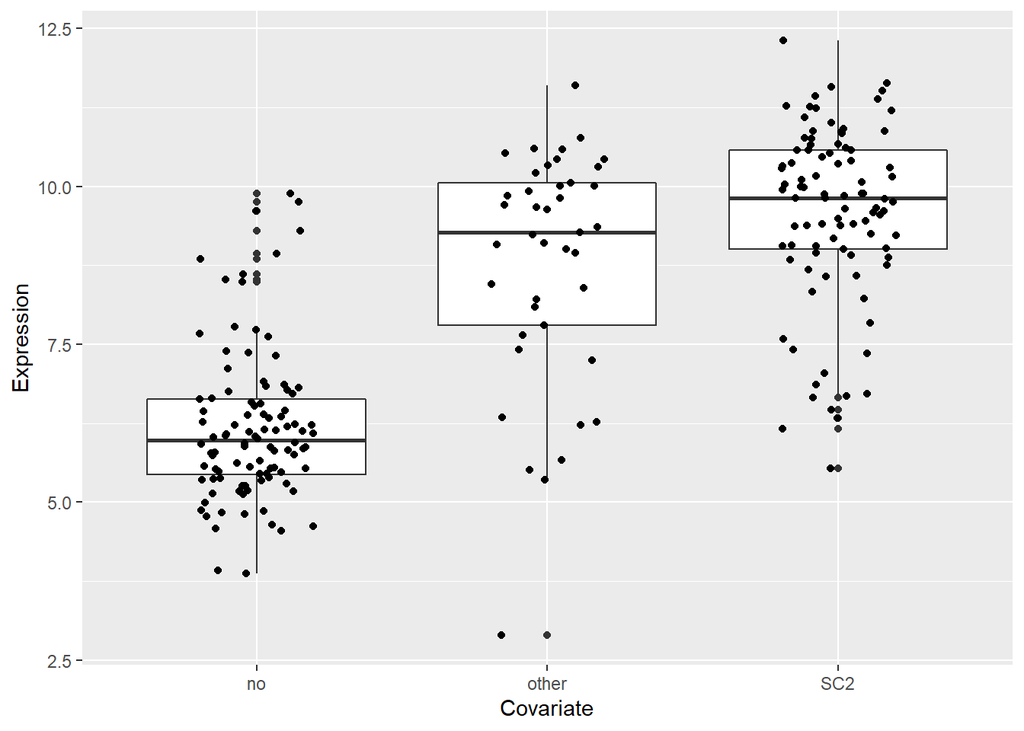

```r
plot_gene <- function(id, expr, covariate) {
  df <- data.frame(Expression=expr[id, ], Covariate=covariate)
  ggplot(df, aes(x=Covariate, y=Expression)) +
    geom_boxplot() +
    geom_jitter(width = .2)
}
plot_gene("ENSG00000126709", norm_counts, covar$group)
```

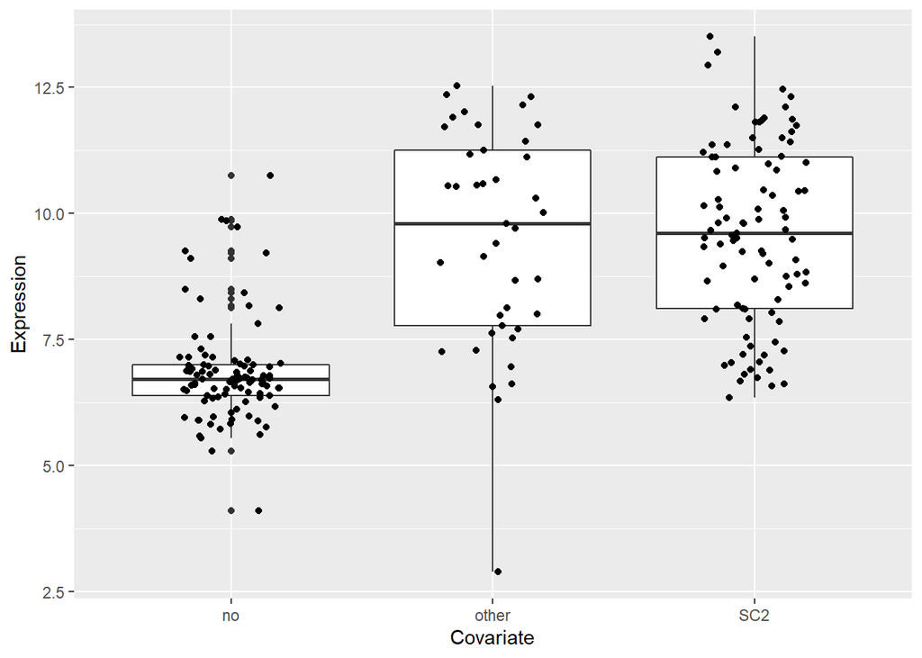

```r
plot_gene("ENSG00000185745", norm_counts, covar$group)
```

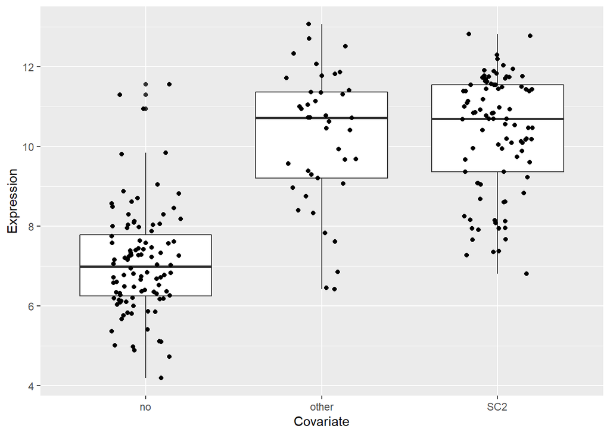

```r
plot_gene("ENSG00000137959", norm_counts, covar$group)
```

Below are plots for 3 most significant gene for other group:

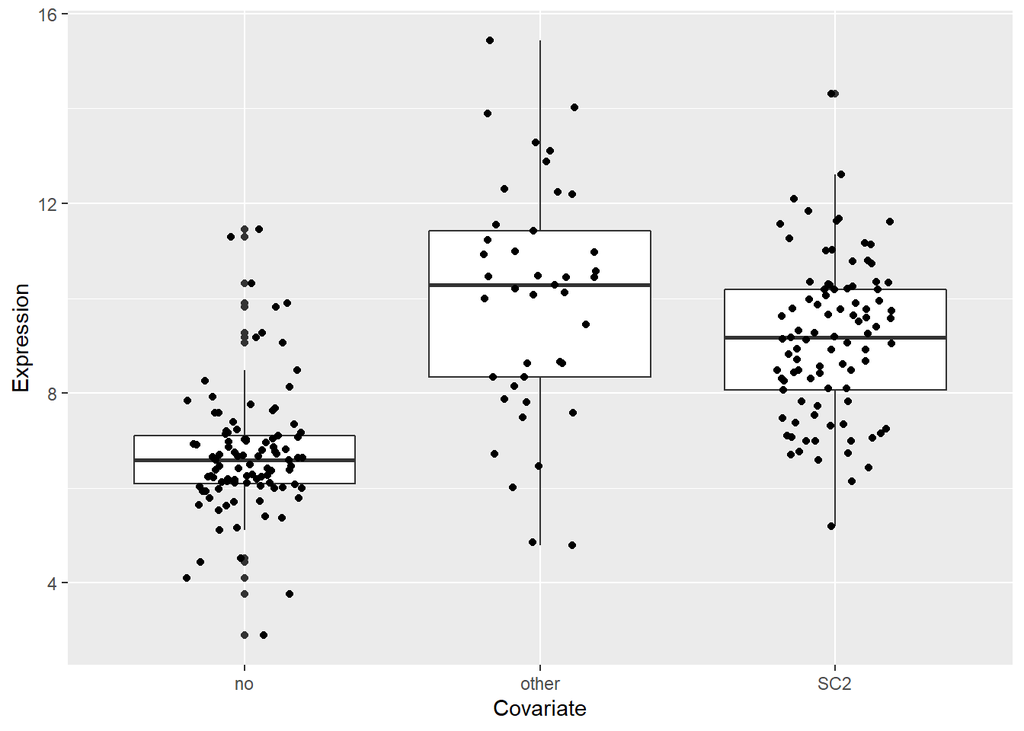

```r
plot_gene("ENSG00000134321", norm_counts, covar$group)
```

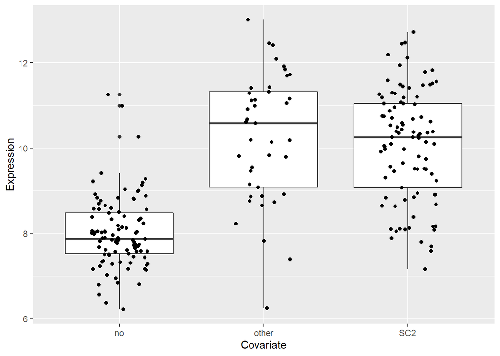

```r
plot_gene("ENSG00000111335", norm_counts, covar$group)
```

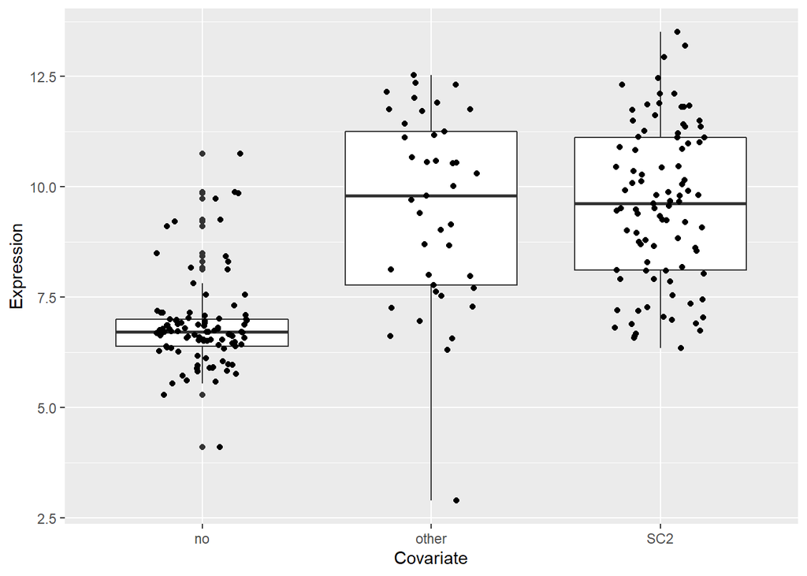

```r
plot_gene("ENSG00000185745", norm_counts, covar$group)
```

# Gene set enrichment

These are tests that look for differentially expressed gene sets in databases that are already available.

## Hypergeometric test and CERNO

To assess a gene’s utility for a gene set in diagnosing an illness, we need an arbitrarily determined significance threshold of 0.001 and at least a twofold change in gene expression.

```r
## Hypergeometric test
## define the "foreground" set
pval_thr <- 1e-3 # define the p value threshold
lfc_thr  <- 1    # define the LFC threshold
sel <- abs(res_other$log2FoldChange) > lfc_thr &
       res_other$padj < pval_thr
fg <- res_other$SYMBOL[sel]
bg <- res_other$SYMBOL
hg_res_other <- tmodHGtest(fg=fg, bg=bg)
## CERNO
gg <- res_other$SYMBOL[ order(res_other$pvalue) ]
ce_res_other <- tmodCERNOtest(gg)
```

We need to use p-value instead of adjusted p-value because adjusted p-value is monotonic on p-value and will not affect the order.The adjusted p-value has a lower resolution (2 different p-values may have the same adjusted p-value due to numerical issues).

```r
## Hypergeometric test
sel <- abs(res_SC2$log2FoldChange) > lfc_thr &
       res_SC2$padj < pval_thr
fg <- res_SC2$SYMBOL[sel]
bg <- res_SC2$SYMBOL
hg_res_SC2 <- tmodHGtest(fg=fg, bg=bg)
## CERNO
gg <- res_SC2$SYMBOL[ order(res_SC2$pvalue) ]
ce_res_SC2 <- tmodCERNOtest(gg)
```

Now we compare the differences between enrichment for “other” disease and SARS-CoV-2. The plot below shows just the order of magnitude of the change.

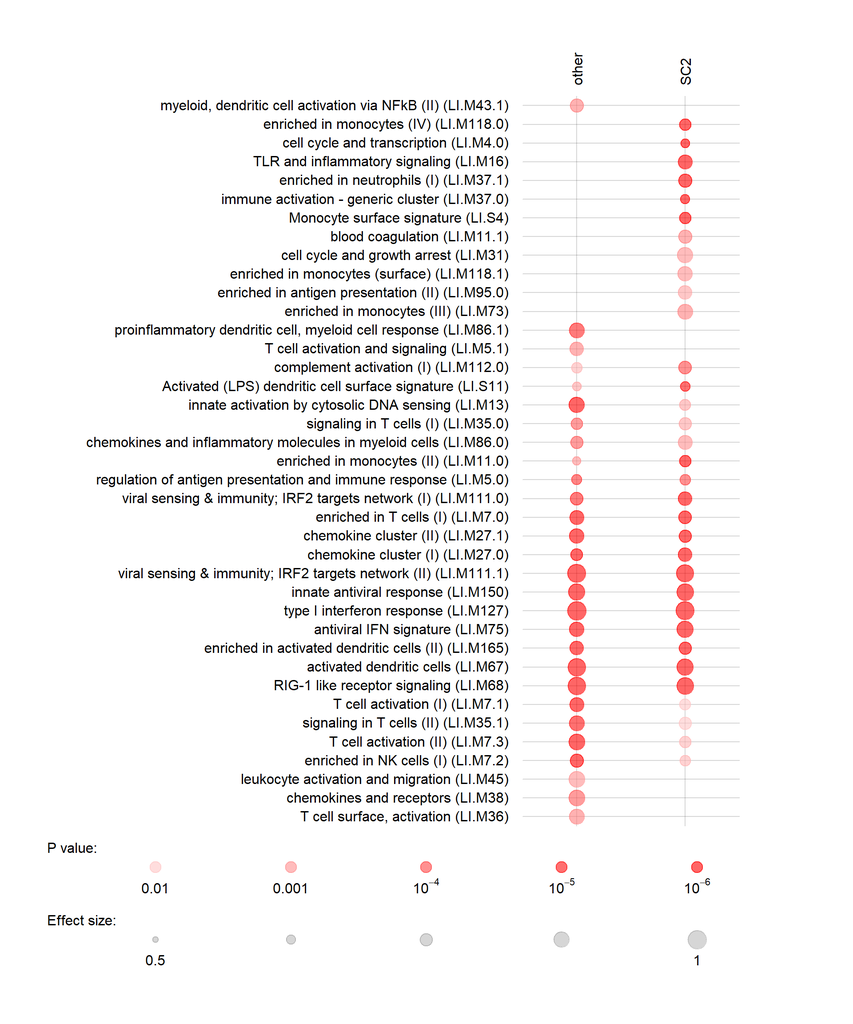

```r
res <- list(other=ce_res_other, SC2=ce_res_SC2)
tmodPanelPlot(res, filter.rows.pval = 1e-3)
```

We have all genes together before the enrichment. To find the differentially expressed ones, we need to check if there is concordance or discordance between groups:

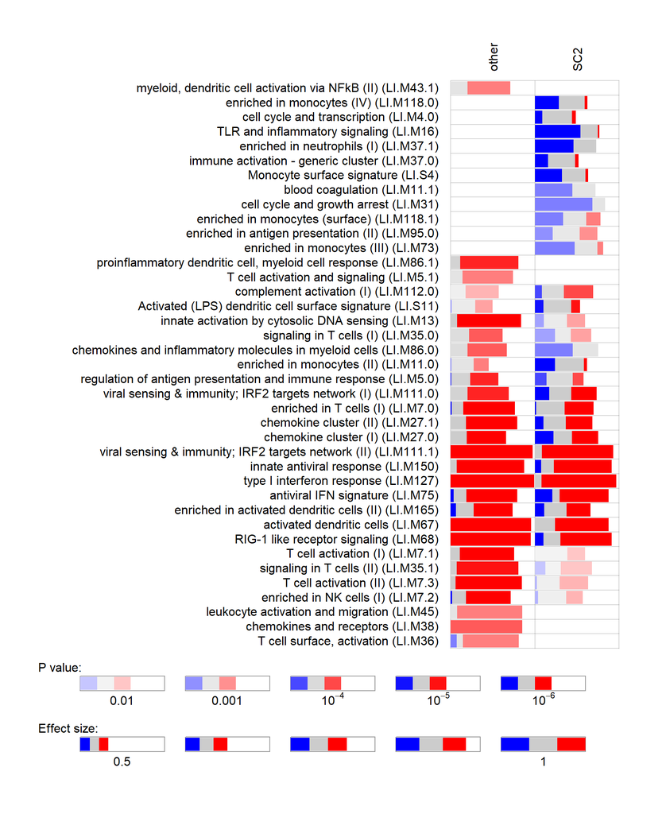

```r
res_merged <- merge(res_other, res_SC2,
  by=c("PrimaryID", "ENSEMBL", "SYMBOL") , suffixes=c(".other", ".SC2"))
lfcs <- res_merged[ , c("log2FoldChange.other", "log2FoldChange.SC2") ]
pvals <- res_merged[ , c("padj.other", "padj.SC2") ]
pie <- tmodDecideTests(res_merged$SYMBOL, lfc = lfcs, pval=pvals)
names(pie) <- names(res)
tmodPanelPlot(res, filter.rows.pval = 1e-3, pie=pie, grid="b")
```

The color blue denotes a decrease in gene expression, whereas the color red denotes an increase.

## Evidence for a gene set difference?

Then, to see if a certain gene set is legitimate in being called differentiating, we may look at the effect magnitude associated with that gene set. It is the same as the p-values-ordered area under the receiver operating curve (ROC) of a gene collection. AUC approaches 1 when a dense collection of genes with strong differentiation potential exists.

Below we inspect effect size of the group with ID `LI.M127` (type I interferon response) for SARS-CoV-2 vs no disease:

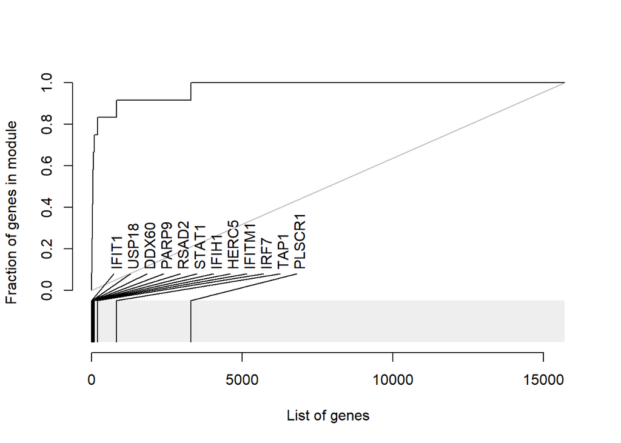

```r
gg <- res_SC2$SYMBOL[ order(res_SC2$pvalue) ]
evidencePlot(gg, m="LI.M127", gene.labels=TRUE)
```

From the previous plot we could already see that the AUC will be high (much closer to 1). On the contrary, group with ID `LI.S11` (Activated (LPS) dendritic cell surface signature) has AUC much lower AUC (something close to 0.6).

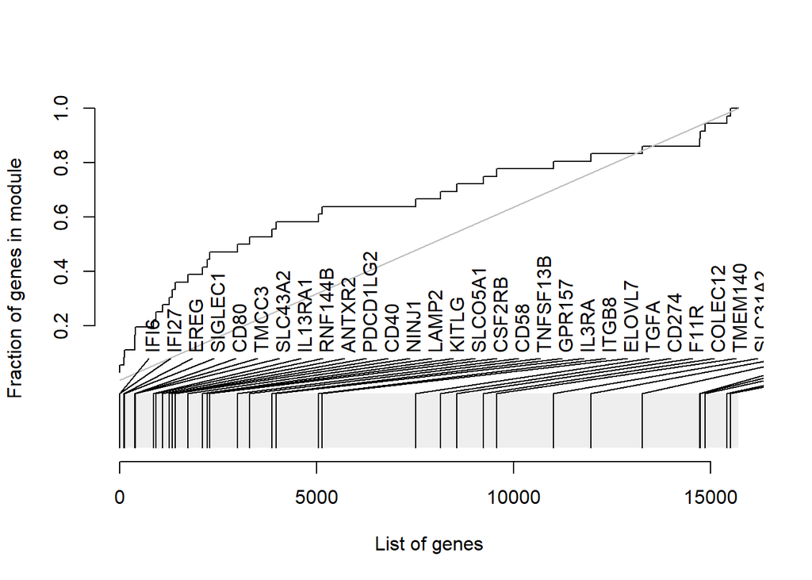

```r
gg <- res_SC2$SYMBOL[ order(res_SC2$pvalue) ]
evidencePlot(gg, m="LI.S11", gene.labels=TRUE)
```

## Gene set

Finally, we look at the genes in the gene set LI.M127 to determine if they differ in expression between SARS-CoV-2 and no illness.

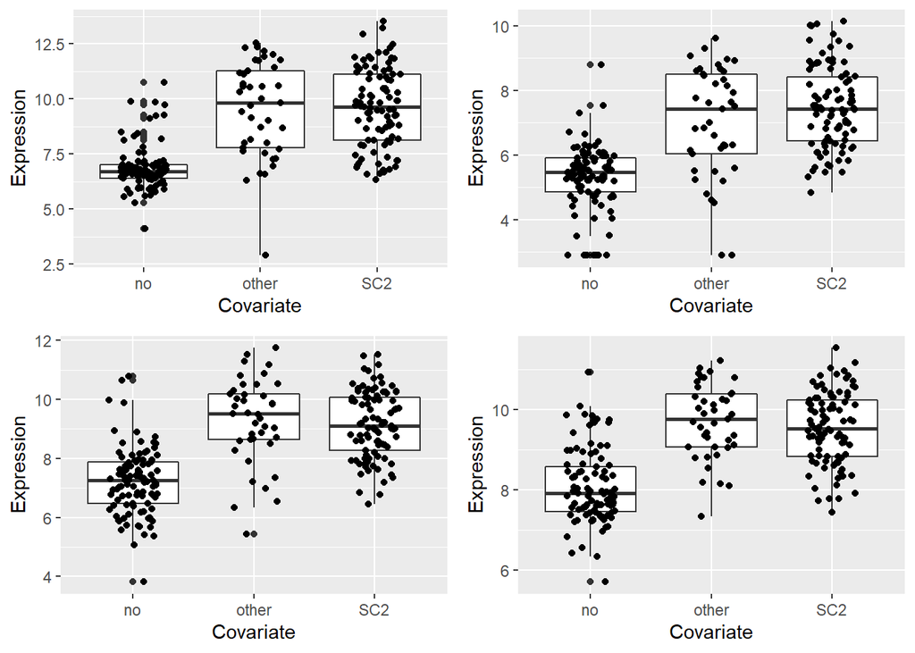

```r
mm <- getModuleMembers("LI.M127")[[1]]
sel <- res_SC2[ res_SC2$SYMBOL %in% mm, ][["PrimaryID"]]
plots <- lapply(sel[1:4], plot_gene, expr=norm_counts, covariate=covar$group)
plot_grid(plotlist=plots, ncol=2)
```

As we can see, these genes are upregulated in SARS-CoV-2 as compared to no disease.